# Accident Severity Prediction for Airlines

## 1. Introduction

The aim of this project is to implement Machine Learning models that can be used to anticipate and classify the severity of an airplane accident based on data collected from past incidents. The aviation industry, can utilize these models to predict the severity of airplane accidents caused due to various factors and, correspondingly, have a plan of action to minimize the risk associated with them.

## 2. Data

The dataset consists of two files:

- **train.csv** This is the training data which has 10000 rows and 12 columns.
- **test.csv** The test data contains 2500 observations and 11 columns.

### Description of columns

- **Accident_ID:** unique id assigned to each row
- **Accident_Type_Code:** the type of accident (factor, not numeric)
- **Cabin_Temperature:** the last recorded temperature before the incident, measured in degrees Fahrenheit
- **Turbulence_In_gforces:** the recorded/estimated turbulence experienced during the accident
- **Control_Metric:** an estimation of how much control the pilot had during the incident given the factors at play
- **Total_Safety_Complaints:** number of complaints from mechanics prior to the accident
- **Days_Since_Inspection:** how long the plane went without inspection before the incident
- **Safety_Score:** a measure of how safe the plane was deemed to be
- **Violations:** number of violations that the aircraft received during inspections
- **Severity (Target variable):** a description (4 level factor) on the severity of the crash

## 3. Methodology

First we obtain the data from the given CSV files. Then, we perform an EDA - Exploratory Data Analysis to analyze the Features and Target variables. The next step is to perform data preprocessing to make the data amenable to further analysis and modeling. We then use some Machine Learning algorithms to perform Training and then make predictions on the Validation data. The model with the best accuracy is selected to perform predictions on the Test dataset. The final results are copied to a csv file for submission.

### 3.1 Loading the libraries and data

First, we import the required libraries and load the train and test csv files into pandas dataframes.

```python
import numpy as np
import pandas as pd
import missingno as msno
import matplotlib.pyplot as plt
import seaborn as sns
plt.style.use('fivethirtyeight')
import warnings
warnings.filterwarnings('ignore')
%matplotlib inline
```

```python
train = pd.read_csv('train.csv')
test = pd.read_csv('test.csv')
```

### 3.2 Exploration of data

The first few rows of the Training and Test datasets are as shown below.

```python
train.head()
```

|  | Severity | Safety_Score | Days_Since_Inspection | Total_Safety_Complaints | Control_Metric | Turbulence_In_gforces | Cabin_Temperature | Accident_Type_Code | Max_Elevation | Violations | Adverse_Weather_Metric | Accident_ID |
| --- | --- | --- | --- | --- | --- | --- | --- | --- | --- | --- | --- | --- |
| 0 | Minor_Damage_And_Injuries | 49.223744 | 14 | 22 | 71.285324 | 0.272118 | 78.04 | 2 | 31335.47682 | 3 | 0.424352 | 7570 |
| 1 | Minor_Damage_And_Injuries | 62.465753 | 10 | 27 | 72.288058 | 0.423939 | 84.54 | 2 | 26024.71106 | 2 | 0.352350 | 12128 |
| 2 | Significant_Damage_And_Fatalities | 63.059361 | 13 | 16 | 66.362808 | 0.322604 | 78.86 | 7 | 39269.05393 | 3 | 0.003364 | 2181 |
| 3 | Significant_Damage_And_Serious_Injuries | 48.082192 | 11 | 9 | 74.703737 | 0.337029 | 81.79 | 3 | 42771.49920 | 1 | 0.211728 | 5946 |
| 4 | Significant_Damage_And_Fatalities | 26.484018 | 13 | 25 | 47.948952 | 0.541140 | 77.16 | 3 | 35509.22852 | 2 | 0.176883 | 9054 |

```python
test.head()
```

|  | Safety_Score | Days_Since_Inspection | Total_Safety_Complaints | Control_Metric | Turbulence_In_gforces | Cabin_Temperature | Accident_Type_Code | Max_Elevation | Violations | Adverse_Weather_Metric | Accident_ID |
| --- | --- | --- | --- | --- | --- | --- | --- | --- | --- | --- | --- |
| 0 | 19.497717 | 16 | 6 | 72.151322 | 0.388959 | 78.32 | 4 | 37949.724386 | 2 | 0.069692 | 1 |
| 1 | 58.173516 | 15 | 3 | 64.585232 | 0.250841 | 78.60 | 7 | 30194.805567 | 2 | 0.002777 | 10 |
| 2 | 33.287671 | 15 | 3 | 64.721969 | 0.336669 | 86.96 | 6 | 17572.925484 | 1 | 0.004316 | 14 |
| 3 | 3.287671 | 21 | 5 | 66.362808 | 0.421775 | 80.86 | 3 | 40209.186341 | 2 | 0.199990 | 17 |
| 4 | 10.867580 | 18 | 2 | 56.107566 | 0.313228 | 79.22 | 2 | 35495.525408 | 2 | 0.483696 | 21 |

```python
train.shape #check the dimensions
```

```
(10000, 12)
```

```python
test.shape
```

```
(2500, 11)
```

The **Descriptive Statistics** for each of the features can be viewed below.

```python
train.describe()
```

|  | Safety_Score | Days_Since_Inspection | Total_Safety_Complaints | Control_Metric | Turbulence_In_gforces | Cabin_Temperature | Accident_Type_Code | Max_Elevation | Violations | Adverse_Weather_Metric | Accident_ID |
| --- | --- | --- | --- | --- | --- | --- | --- | --- | --- | --- | --- |
| count | 10000.000000 | 10000.000000 | 10000.000000 | 10000.000000 | 10000.000000 | 10000.000000 | 10000.000000 | 10000.000000 | 10000.00000 | 10000.000000 | 10000.000000 |
| mean | 41.876406 | 12.931100 | 6.564300 | 65.145324 | 0.381495 | 79.969331 | 3.814900 | 32001.803282 | 2.01220 | 0.255635 | 6266.554200 |
| std | 16.138072 | 3.539803 | 6.971982 | 11.882934 | 0.121301 | 2.759739 | 1.902577 | 9431.995196 | 1.03998 | 0.381128 | 3610.170288 |
| min | 0.000000 | 1.000000 | 0.000000 | 0.000000 | 0.134000 | 74.740000 | 1.000000 | 831.695553 | 0.00000 | 0.000316 | 2.000000 |
| 25% | 30.593607 | 11.000000 | 2.000000 | 56.927985 | 0.293665 | 77.960000 | 2.000000 | 25757.636910 | 1.00000 | 0.012063 | 3139.750000 |
| 50% | 41.278539 | 13.000000 | 4.000000 | 65.587967 | 0.365879 | 79.540000 | 4.000000 | 32060.336420 | 2.00000 | 0.074467 | 6280.500000 |
| 75% | 52.511416 | 15.000000 | 9.000000 | 73.336372 | 0.451346 | 81.560000 | 5.000000 | 38380.641515 | 3.00000 | 0.354059 | 9391.500000 |
| max | 100.000000 | 23.000000 | 54.000000 | 100.000000 | 0.882648 | 97.510000 | 7.000000 | 64297.651220 | 5.00000 | 2.365378 | 12500.000000 |

```python
test.describe()
```

|  | Safety_Score | Days_Since_Inspection | Total_Safety_Complaints | Control_Metric | Turbulence_In_gforces | Cabin_Temperature | Accident_Type_Code | Max_Elevation | Violations | Adverse_Weather_Metric | Accident_ID |
| --- | --- | --- | --- | --- | --- | --- | --- | --- | --- | --- | --- |
| count | 2500.000000 | 2500.000000 | 2500.000000 | 2500.000000 | 2500.000000 | 2500.000000 | 2500.000000 | 2500.000000 | 2500.000000 | 2500.000000 | 2500.000000 |
| mean | 41.825224 | 12.946400 | 6.574800 | 65.368058 | 0.376197 | 79.993068 | 3.853600 | 32383.134179 | 1.990800 | 0.250886 | 6186.283200 |
| std | 16.280187 | 3.523364 | 7.179542 | 11.442005 | 0.116960 | 2.713833 | 1.877652 | 9485.096436 | 1.018592 | 0.387663 | 3602.235035 |
| min | 0.000000 | 1.000000 | 0.000000 | 20.966272 | 0.143376 | 74.740000 | 1.000000 | 831.695553 | 0.000000 | 0.000368 | 1.000000 |
| 25% | 30.593607 | 11.000000 | 1.000000 | 57.702826 | 0.292583 | 77.930000 | 2.000000 | 26008.851717 | 1.000000 | 0.013136 | 3071.750000 |
| 50% | 41.461187 | 13.000000 | 4.000000 | 66.066545 | 0.357404 | 79.600000 | 4.000000 | 32472.865497 | 2.000000 | 0.072466 | 6159.500000 |
| 75% | 52.751142 | 15.000000 | 9.000000 | 73.119872 | 0.441699 | 81.530000 | 5.000000 | 38759.519071 | 3.000000 | 0.315407 | 9309.250000 |
| max | 100.000000 | 23.000000 | 54.000000 | 97.994531 | 0.881926 | 94.200000 | 7.000000 | 62315.408444 | 5.000000 | 2.365378 | 12493.000000 |

#### Check for missing values

```python
train.isna().sum()
```

```
Severity                   0
Safety_Score               0
Days_Since_Inspection      0
Total_Safety_Complaints    0
Control_Metric             0
Turbulence_In_gforces      0
Cabin_Temperature          0
Accident_Type_Code         0
Max_Elevation              0
Violations                 0
Adverse_Weather_Metric     0
Accident_ID                0
dtype: int64
```

As we can see above, there are no missing values in the training dataset.

```python
test.isna().sum()
```

```
Safety_Score               0
Days_Since_Inspection      0
Total_Safety_Complaints    0
Control_Metric             0
Turbulence_In_gforces      0
Cabin_Temperature          0
Accident_Type_Code         0
Max_Elevation              0
Violations                 0
Adverse_Weather_Metric     0
Accident_ID                0
dtype: int64
```

Similarly, there are no missing values present in the test dataset.

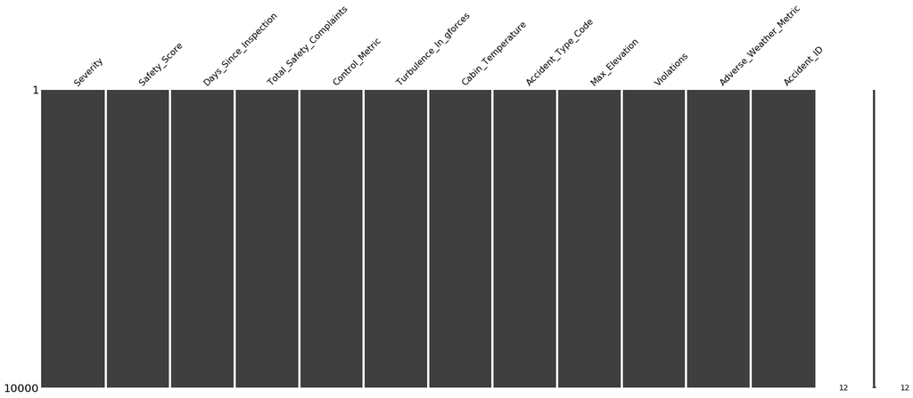

```python
msno.matrix(train)
```

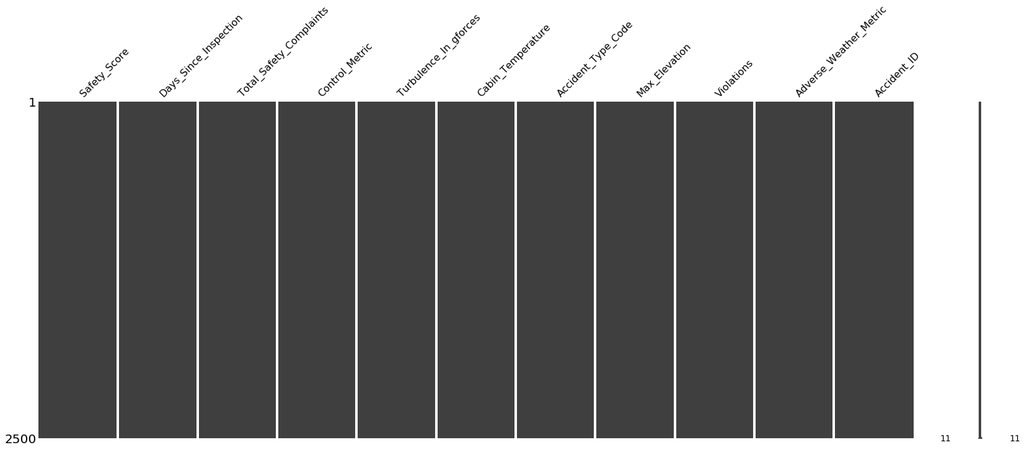

```python
msno.matrix(test)
```

The above plots confirm that there are no missing values in the dataset.

### Visualizations of Features

First we explore the column **Severity** which is the target/response variable.

```python
print('Severity Values:', train['Severity'].unique())
```

```
Severity Values: ['Minor_Damage_And_Injuries' 'Significant_Damage_And_Fatalities'
 'Significant_Damage_And_Serious_Injuries' 'Highly_Fatal_And_Damaging']
```

It has four unique values, according to the severity of the incident recorded.

```python
target = train['Severity']
```

```python
target.value_counts(normalize=True)
```

```
Highly_Fatal_And_Damaging                  0.3049
Significant_Damage_And_Serious_Injuries    0.2729
Minor_Damage_And_Injuries                  0.2527
Significant_Damage_And_Fatalities          0.1695
Name: Severity, dtype: float64
```

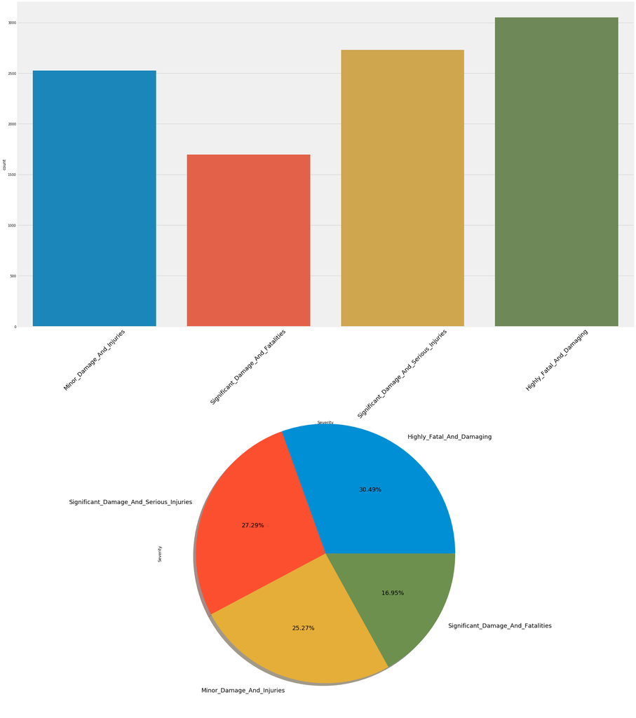

```python
fig,ax=plt.subplots(2,1,figsize=(30,40))
target.value_counts(normalize = True).plot.pie(autopct='%2.2f%%', shadow = True, textprops={'fontsize': 18})
ax[0].set_xticklabels(ax[0].get_xticklabels(), rotation=45, fontsize = 18)
sns.countplot('Severity',data=train,ax=ax[0])
plt.show()
```

The above bar and pie charts display the distribution of the four Severity levels in Training data. The **Highly_Fatal_And_Damaging** incidents are the majority, followed by **Significant_Damage_And_Serious_Injuries**, **Minor_Damage_And_Injuries** and the least commonly occuring incidents are of the type **Significant_Damage_And_Fatalities**.

### Checking Correlation between features

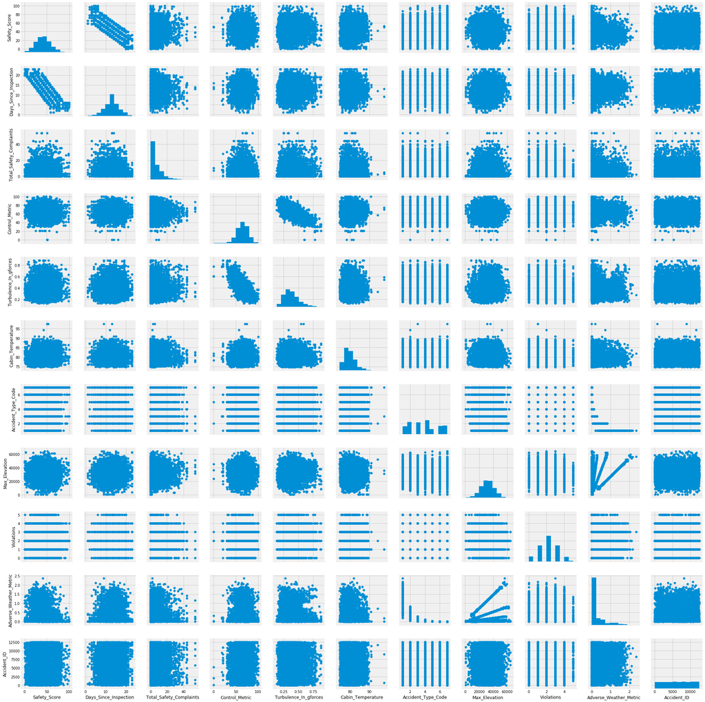

```python
fig.set_size_inches(10,8)
p1 = sns.PairGrid(train)
p1 = p1.map_diag(plt.hist)
p1 = p1.map_offdiag(plt.scatter)
```

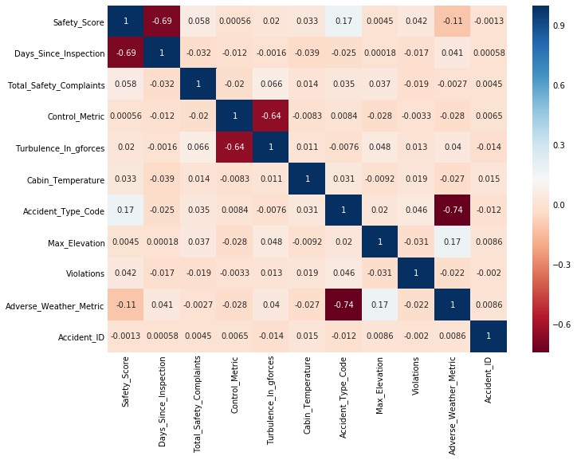

```python
sns.heatmap(train.corr(), annot = True, cmap = 'RdBu')
fig=plt.gcf()
fig.set_size_inches(10,8)
plt.show()
```

As seen in the pairgrid and heatmap above, few of the features display some correlation. For example, **Safety_Score** and **Days_Since_Inspection** are negatively correlated meaning, more the Days since Inspection, lesser the Safety score, which is as expected. Similarly, there is negative correlation between Control_Metric and Turbulence_In_gforces, as well as Accident_Type_Code and Adverse_Weather_Metric.

### 3.2 Data Preprocessing

### Converting Target to Numerical

We will convert the target variable Severity to a numerical variable **Severity_Label** for convenience of analysis.

```python
train['Severity_Label']=train['Severity'].map({'Highly_Fatal_And_Damaging':1,'Significant_Damage_And_Fatalities':2,'Significant_Damage_And_Serious_Injuries':3,'Minor_Damage_And_Injuries':4})
```

```python
train.corr()['Severity_Label']
```

```
Safety_Score               0.308136
Days_Since_Inspection      0.033429
Total_Safety_Complaints    0.026801
Control_Metric            -0.013701
Turbulence_In_gforces      0.031615
Cabin_Temperature         -0.019172
Accident_Type_Code        -0.018977
Max_Elevation              0.019331
Violations                -0.004590
Adverse_Weather_Metric    -0.029530
Accident_ID               -0.001033
Severity_Label             1.000000
Name: Severity_Label, dtype: float64
```

We can check the correlation betwween the new target variable and other features as shown above.

```python
train.drop('Severity',axis=1,inplace=True) #drop duplicate column for Severity
train.head()
```

|  | Safety_Score | Days_Since_Inspection | Total_Safety_Complaints | Control_Metric | Turbulence_In_gforces | Cabin_Temperature | Accident_Type_Code | Max_Elevation | Violations | Adverse_Weather_Metric | Accident_ID | Severity_Label |
| --- | --- | --- | --- | --- | --- | --- | --- | --- | --- | --- | --- | --- |
| 0 | 49.223744 | 14 | 22 | 71.285324 | 0.272118 | 78.04 | 2 | 31335.47682 | 3 | 0.424352 | 7570 | 4 |
| 1 | 62.465753 | 10 | 27 | 72.288058 | 0.423939 | 84.54 | 2 | 26024.71106 | 2 | 0.352350 | 12128 | 4 |
| 2 | 63.059361 | 13 | 16 | 66.362808 | 0.322604 | 78.86 | 7 | 39269.05393 | 3 | 0.003364 | 2181 | 2 |
| 3 | 48.082192 | 11 | 9 | 74.703737 | 0.337029 | 81.79 | 3 | 42771.49920 | 1 | 0.211728 | 5946 | 3 |
| 4 | 26.484018 | 13 | 25 | 47.948952 | 0.541140 | 77.16 | 3 | 35509.22852 | 2 | 0.176883 | 9054 | 2 |

### Standardizing the Features

```python
from sklearn.model_selection import train_test_split
from sklearn.preprocessing import StandardScaler
```

```python
Y = train['Severity_Label'] #divide the columns into input X and output Y
X = train.drop('Severity_Label', axis = 1)
```

```python
X.shape
```

```
(10000, 11)
```

```python
Y.shape
```

```
(10000,)
```

It is a good practice to standardize the variables by removing the mean and scaling to unit variance. The reason is, if a feature has a variance that is of magnitude much larger that others, it might dominate the objective function and make the estimator unable to learn from other features correctly as expected. We standardize the input X and the test data as well.

```python
X=StandardScaler().fit(X).transform(X.astype(float))
X.shape
```

```
(10000, 11)
```

### 3.3 Modeling the Data

We fit a few Machine Learning models on Training data and perfom predications on the Validation data. The model which gives the best accuracy will be used for predicting on the test dataset.

### Splitting training data

We perform a 70-30 split of the training dataset into Training and Validation data

```python
X_train,X_test,Y_train,Y_test=train_test_split(X,Y,test_size=0.3,random_state=0)
```

```python
from sklearn import linear_model
from sklearn.linear_model import LogisticRegression
from sklearn.ensemble import RandomForestClassifier
from sklearn.tree import DecisionTreeClassifier
from sklearn.neighbors import KNeighborsClassifier
from sklearn.svm import SVC, LinearSVC
from sklearn.naive_bayes import GaussianNB
from sklearn.linear_model import Perceptron, SGDClassifier

from sklearn.metrics import accuracy_score  #for accuracy
from sklearn.model_selection import KFold #for K-fold cross validation
from sklearn.model_selection import cross_val_score # for score evaluation
from sklearn.model_selection import cross_val_predict # for prediction
```

### K Nearest Neighbors

We first determine the best k value based on maximum accuracy score, for k values ranging from 3 to 29.

```python
acc_list = []
for k in range(3,30):
    knn = KNeighborsClassifier(n_neighbors = k)
    knn.fit(X_train,Y_train)
    knn_pred = knn.predict(X_test)
    #acc_array[i-1] = round(accuracy_score(knn_pred,Y_test)*100,2)
    acc_list.append(round(accuracy_score(knn_pred,Y_test)*100,2))
#acc_list
max_acc = max(acc_list)
optimum_k = acc_list.index(max(acc_list)) + 3
print('The maximum accuracy',max_acc, 'is obtained for k =',optimum_k)
```

```
The maximum accuracy 65.7 is obtained for k = 14
```

We choose k = 14 as this gives us the best accuracy. We then fit the model on Training and predict on the Validation data.

```python
knn = KNeighborsClassifier(n_neighbors = 14)
knn.fit(X_train, Y_train)
knn_pred = knn.predict(X_test)
knn_acc = round(accuracy_score(knn_pred,Y_test) * 100, 2)
kfold = KFold(n_splits=10, random_state=22)
cv_knn=cross_val_score(knn,X,Y,cv=10,scoring='accuracy')

print('The accuracy of the K Nearest Neighbors Classifier is',knn_acc)
print('The cross validated score for K Nearest Neighbors Classifier is:',round(cv_knn.mean()*100,2))
```

```
The accuracy of the K Nearest Neighbors Classifier is 65.7
The cross validated score for K Nearest Neighbors Classifier is: 67.46
```

### Logistic Regression

We fit the Logistic Regression model on the Training data and perform predictions on the Validation set.

```python
logr = LogisticRegression()
logr.fit(X_train,Y_train)
logr_pred=logr.predict(X_test)
logr_acc = round(accuracy_score(logr_pred,Y_test)*100,2)
kfold = KFold(n_splits=10, random_state=0) # Splitting the data into 10 equal parts
cv_logr=cross_val_score(logr,X,Y,cv=10,scoring='accuracy')

print('The accuracy of Logistic Regression model is',logr_acc)
print('The cross validated score for Logistic Regression model is:',round(cv_logr.mean()*100,2))
```

```
The accuracy of Logistic Regression model is 60.0
The cross validated score for Logistic Regression model is: 60.08
```

In a similary way, we train the models Gaussian Naive Bayes, Decision Trees, Support Vector Machines, Stochastic Gradient Descent, and Random Forest Classifier.

### Gaussian Naive Bayes

```python
gnb = GaussianNB()
gnb.fit(X_train,Y_train)
gnb_pred = gnb.predict(X_test)
#gnb_acc_train = round(gnb.score(X_train,Y_train)*100,2)
gnb_acc = round(accuracy_score(gnb_pred,Y_test)*100,2)
kfold = KFold(n_splits=10, random_state=0)
cv_gnb=cross_val_score(gnb,X,Y,cv=10,scoring='accuracy')

print('The accuracy of the Gaussian Naive Bayes Classifier is',gnb_acc)
print('The cross validated score for Gaussian Naive Bayes classifier is:',round(cv_gnb.mean()*100,2))
```

```
The accuracy of the Gaussian Naive Bayes Classifier is 45.87
The cross validated score for Gaussian Naive Bayes classifier is: 45.66
```

### Decision Trees

```python
tree = DecisionTreeClassifier()
tree.fit(X_train, Y_train)
tree_pred = tree.predict(X_test)
tree_acc = round(accuracy_score(tree_pred, Y_test) * 100, 2)
kfold = KFold(n_splits=10, random_state=0)
cv_tree=cross_val_score(tree,X,Y,cv=10,scoring='accuracy')

print('The accuracy of the Decision Tree Classifier is',tree_acc)
print('The cross validated score for Decision Tree Classifier is:',round(cv_tree.mean()*100,2))
```

```
The accuracy of the Decision Tree Classifier is 90.37
The cross validated score for Decision Tree Classifier is: 92.85
```

### Support Vector Machines

```python
svm = SVC()
svm.fit(X_train, Y_train)
svm_pred = svm.predict(X_test)
svm_acc = round(accuracy_score(svm_pred, Y_test) * 100, 2)
kfold = KFold(n_splits=10, random_state=0)
cv_svm=cross_val_score(svm,X,Y,cv=10,scoring='accuracy')

print('The accuracy of the Support Vector Machines Classifier is',svm_acc)
print('The cross validated score for Support Vector Machines Classifier is:',round(cv_svm.mean()*100,2))
```

```
The accuracy of the Support Vector Machines Classifier is 86.43
The cross validated score for Support Vector Machines Classifier is: 86.71
```

### Stochastic Gradient Descent Classifier

```python
sgd = SGDClassifier()
sgd.fit(X_train, Y_train)
sgd_pred = sgd.predict(X_test)
sgd_acc = round(accuracy_score(sgd_pred, Y_test) * 100, 2)
#kfold = KFold(n_splits=10, random_state=0)
cv_sgd=cross_val_score(sgd,X,Y,cv=10,scoring='accuracy')

print('The accuracy of the SGD classifier is', sgd_acc)
print('The cross validated score for Decision Tree Classifier is:',round(cv_sgd.mean()*100,2))
```

```
The accuracy of the SGD classifier is 48.9
The cross validated score for Decision Tree Classifier is: 45.57
```

### Random Forests

```python
rfc = RandomForestClassifier(n_estimators=100)
rfc.fit(X_train, Y_train)
rfc_pred = rfc.predict(X_test)
rfc_acc = round(accuracy_score(rfc_pred, Y_test) * 100, 2)
#kfold = KFold(n_splits=10, random_state=0)
cv_rfc=cross_val_score(rfc,X,Y,cv=10,scoring='accuracy')


print('The accuracy of the Random Forest classifier is', rfc_acc)
print('The cross validated score for Decision Tree Classifier is:',round(cv_rfc.mean()*100,2))
```

```
The accuracy of the Random Forest classifier is 90.7
The cross validated score for Decision Tree Classifier is: 92.76
```

### Summarizing the Models

We create a dataframe to compare all the models.

```python
Summary = pd.DataFrame({
    'Model': ['KNN', 'Logistic Regression', 'Gaussian Naive Bayes', 'Support Vector Machines', 'Decision Tree Classifier',
              'Stochastic Gradient Descent Classifier', 'Random Forests'],
    'Accuracy': [knn_acc, logr_acc, gnb_acc, svm_acc, tree_acc, sgd_acc, rfc_acc]})
Summary_df = Summary.sort_values(by='Accuracy', ascending=False)
Summary_df = Summary_df.set_index('Model')
Summary_df
```

| Model | Accuracy |
| --- | --- |
| Random Forests | 90.70 |
| Decision Tree Classifier | 90.37 |
| Support Vector Machines | 86.43 |
| KNN | 65.70 |
| Logistic Regression | 60.00 |
| Stochastic Gradient Descent Classifier | 48.90 |
| Gaussian Naive Bayes | 45.87 |

As seen above, **Decision Trees** and **Random Forests** provide the best accuracy and we choose these models to run predictions on the Test dataset.

### Running best model on Test data

```python
test_X = StandardScaler().fit(test).transform(test.astype(float)) # standardizing the test data
test_X.shape
```

```
(2500, 11)
```

#### Predicting using the above generated Decison Tree model

```python
test_pred_tree = tree.predict(test_X)
test_pred_tree = pd.DataFrame(test_pred_tree)
test_pred_tree.columns = ['Severity_Label']
test_pred_tree.head()
```

|  | Severity_Label |
| --- | --- |
| 0 | 1 |
| 1 | 2 |
| 2 | 3 |
| 3 | 3 |
| 4 | 2 |

```python
# reverse mapping the Severity variable from Numerical to Factor
test_pred_tree['Severity']=test_pred_tree['Severity_Label'].map({1:'Highly_Fatal_And_Damaging',2:'Significant_Damage_And_Fatalities',3:'Significant_Damage_And_Serious_Injuries',4:'Minor_Damage_And_Injuries'})
```

```python
test_pred_tree.drop('Severity_Label', axis=1,inplace=True)
test_pred_tree.head()
```

|  | Severity |
| --- | --- |
| 0 | Highly_Fatal_And_Damaging |
| 1 | Significant_Damage_And_Fatalities |
| 2 | Significant_Damage_And_Serious_Injuries |
| 3 | Significant_Damage_And_Serious_Injuries |
| 4 | Significant_Damage_And_Fatalities |

#### Prediction using the Random Forest model

```python
test_pred_rfc = rfc.predict(test_X)
test_pred_rfc = pd.DataFrame(test_pred_rfc)
test_pred_rfc.columns = ['Severity_Label']
test_pred_rfc['Severity']=test_pred_rfc['Severity_Label'].map({1:'Highly_Fatal_And_Damaging',2:'Significant_Damage_And_Fatalities',3:'Significant_Damage_And_Serious_Injuries',4:'Minor_Damage_And_Injuries'})
test_pred_rfc.drop('Severity_Label', axis=1,inplace=True)
test_pred_rfc.head()
```

|  | Severity |
| --- | --- |
| 0 | Highly_Fatal_And_Damaging |
| 1 | Significant_Damage_And_Fatalities |
| 2 | Significant_Damage_And_Serious_Injuries |
| 3 | Highly_Fatal_And_Damaging |
| 4 | Significant_Damage_And_Fatalities |

### Determining Importance of Features

The Random Forest Classifier can be used to gauge the importance of each feature in the dataset.

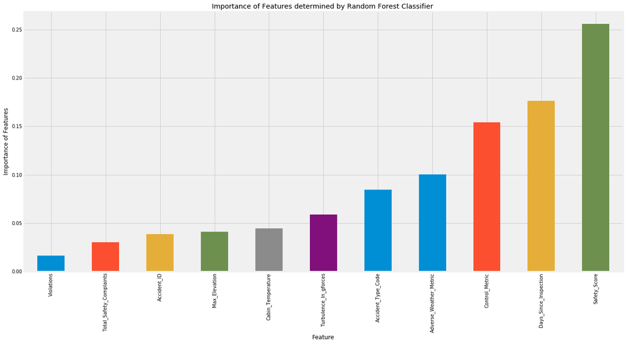

```python
X = train.drop('Severity_Label', axis = 1)
importances=pd.Series(rfc.feature_importances_, index=X.columns)
importances.sort_values().plot(kind='bar', figsize=(20,10))
plt.xlabel('Feature')
plt.ylabel('Importance of Features')
plt.title("Importance of Features determined by Random Forest Classifier ")
```

As seen above, the features **Safety_Score**, **Days_Since_Inspection**, **Control_metric** and **Adverse_Weather_Metric** seem to play the most important roles in causing Airline accidents.

## 4. Results and Conclusion

We create a dataframe to store the predicted results (Severity for each corresponding Accident ID). The final results are also copied to a csv file submission.csv.

```python
result_df = test[['Accident_ID']]
result_df['Severity'] = test_pred_rfc['Severity']
result_df.to_csv('submission.csv', index=False)
result_df.head()
```

|  | Accident_ID | Severity |
| --- | --- | --- |
| 0 | 1 | Highly_Fatal_And_Damaging |
| 1 | 10 | Significant_Damage_And_Fatalities |
| 2 | 14 | Significant_Damage_And_Serious_Injuries |
| 3 | 17 | Highly_Fatal_And_Damaging |
| 4 | 21 | Significant_Damage_And_Fatalities |

As a conclusion, we can observe that, Random Forests and Decision Trees are the best Machine Learning models in terms of accuracy, for this particular dataset.